# Video Game Sales Simple Analysis

Jing Li

December 04, 2016

# Data Import

The dataset was downloaded from [kaggle.com](https://www.kaggle.com/gregorut/videogamesales).

# Data Overview

There are **11** variables and **16,598** observations.

The variables are:

- `Rank`: Ranking of overall sales
- `Name`: The game name
- `Platform`: Platform of the games release (i.e. PC,PS4, etc.)
- `Year`: Year of the game’s release
- `Genre`: Genre of the game
- `Publisher`: Publisher of the game
- `NA_Sales`: Sales in North America (in millions)
- `EU_Sales`: Sales in Europe (in millions)
- `JP_Sales`: Sales in Japan (in millions)
- `Other_Sales`: Sales in the rest of the world (in millions)
- `Global_Sales`: Total worldwide sales (in millions)

*(sales are the number of copies)*

Below are the summary statistics for the numerical variables:

```r
vgsales %>%
  select(dplyr::contains("_Sales")) %>%
  summary() %>%
  pandoc.table(style = "simple")
```

```
##
##
##    NA_Sales        EU_Sales         JP_Sales       Other_Sales     Global_Sales
## --------------- --------------- ---------------- ---------------- ---------------
## Min.   : 0.0000 Min.   : 0.0000 Min.   : 0.00000 Min.   : 0.00000 Min.   : 0.0100
## 1st Qu.: 0.0000 1st Qu.: 0.0000 1st Qu.: 0.00000 1st Qu.: 0.00000 1st Qu.: 0.0600
## Median : 0.0800 Median : 0.0200 Median : 0.00000 Median : 0.01000 Median : 0.1700
## Mean   : 0.2647 Mean   : 0.1467 Mean   : 0.07778 Mean   : 0.04806 Mean   : 0.5374
## 3rd Qu.: 0.2400 3rd Qu.: 0.1100 3rd Qu.: 0.04000 3rd Qu.: 0.04000 3rd Qu.: 0.4700
## Max.   :41.4900 Max.   :29.0200 Max.   :10.22000 Max.   :10.57000 Max.   :82.7400
```

# Data Visualizations

## 1. Genre Popularity over the Years

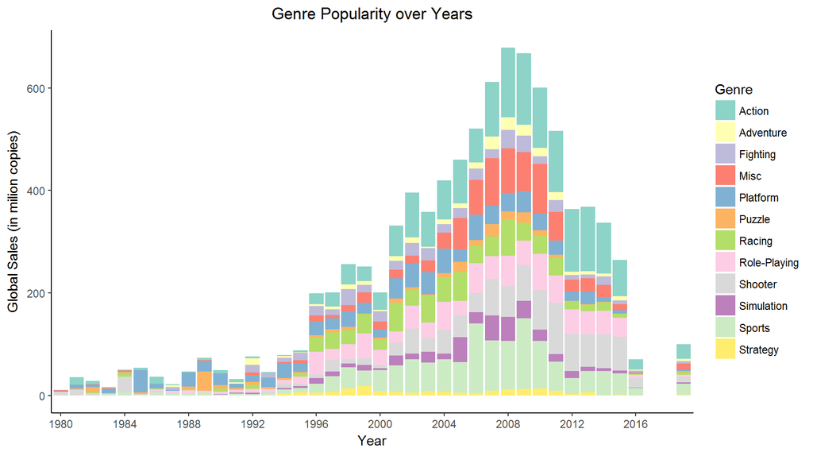

```r
vgsales %>%
  ggplot(aes(x = Year, y = Global_Sales, fill = Genre)) +
  geom_bar(stat = "identity") +
  labs(title = "Genre Popularity over Years", x = "Year", y = "Global Sales (in milion copies)") +
  scale_x_discrete(breaks = as.character(seq(from = 1980, to = 2016, by = 4))) +
  theme_classic() +
  theme(plot.title = element_text(hjust = 0.5)) +
  scale_fill_brewer(palette = "Set3")
```

It seems that **Action** game is the dominating genre since 2000, and **Sports** game is usually the second popular genre. Also, the global sales peaked around **2008** and then started to drop dramatically.

## 2. Genre Sales by Regions

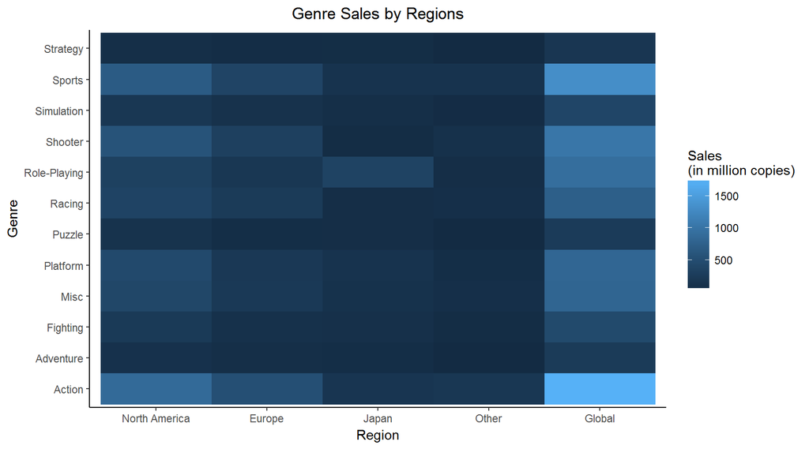

```r
vgsales %>%
  group_by(Genre) %>%
  summarise_if(is.numeric, sum) %>%
  ungroup() %>%
  gather(Region, Sales, NA_Sales:Global_Sales) %>%
  mutate(Region = str_replace(Region, "_Sales$", "") %>%
           factor(levels = c("NA", "EU", "JP", "Other", "Global"),
                  labels = c("North America", "Europe", "Japan", "Other", "Global"))) %>%
  ggplot(aes(x = Region, y = Genre)) +
  geom_tile(aes(fill = Sales)) +
  labs(title = "Genre Sales by Regions", x = "Region", y = "Genre") +
  scale_fill_continuous(name = "Sales\n(in million copies)") +
  theme_classic() +
  theme(plot.title = element_text(hjust = 0.5), legend.title.align = 0)
```

The sales numbers are aggregated to remove the time dimension. From the graph above, we can see that in terms of sales, people from `North America` and those from `Europe` have very similar tastes as they all prefer **Action**, **Sports**, **Shooter**, and **Platform** over others, though in terms of absolute numbers, games are sold more in `North America` than in `Europe`.

However, in `Japan`, the most popular genre is **Role-Playing**, which might be due to the cultural differences.

Globally, **Action** and **Sports** are the most popular genres.

## 3. Global Sales by Genre of the Top 10 Publishers

Below shows the **Top 10** Publishers in terms of cumulative global sales over the years:

```r
top10 <- vgsales %>%
  group_by(Publisher) %>%
  summarise(Cum_Sales = sum(Global_Sales)) %>%
  arrange(desc(Cum_Sales)) %>%
  top_n(10)
top10 %>% pandoc.table(style = "rmarkdown")
```

```
##
##
## |          Publisher           |  Cum_Sales  |
## |:----------------------------:|:-----------:|
## |           Nintendo           |   1786.56   |
## |       Electronic Arts        |   1110.32   |
## |          Activision          |   727.46    |
## | Sony Computer Entertainment  |   607.50    |
## |           Ubisoft            |   474.72    |
## |     Take-Two Interactive     |   399.54    |
## |             THQ              |   340.77    |
## | Konami Digital Entertainment |   283.64    |
## |             Sega             |   272.99    |
## |      Namco Bandai Games      |   254.09    |
```

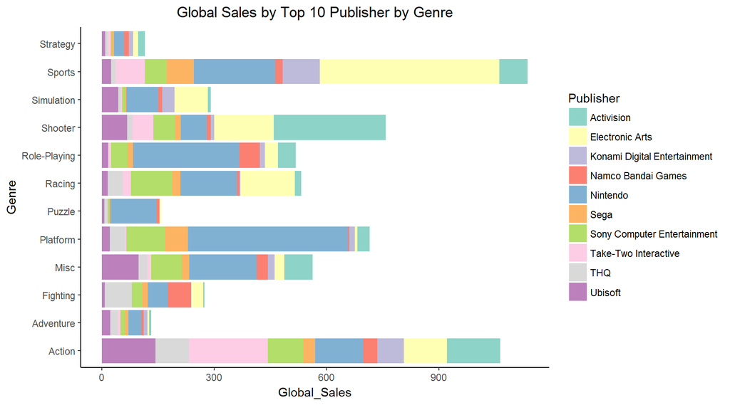

```r
publishers <- top10$Publisher
vgsales %>%
  filter(Publisher %in% publishers) %>%
  ggplot(aes(x = Genre, y = Global_Sales)) +
  geom_bar(stat = "identity", aes(fill = Publisher)) +
  coord_flip() +
  labs(title = "Global Sales by Top 10 Publisher by Genre", xlab = "Cumulative Global Sales") +
  theme_classic() +
  theme(plot.title = element_text(hjust = 0.5)) +
  scale_fill_brewer(palette = "Set3")
```

Within the Top 10 publishers, **Sports** games have the greatest global sales, followed by **Action** games. **Electronic Arts** has absolute power over the **Sports** games, while **Take-Two Interactive** is the No. 1 **Action** game publisher. Although **Puzzle**, **Role Playing** and **Platform** games don’t have the most sales, in those worlds, **Nintendo** reigns. And **Shooter** game is **Activision**’s playground.

## 4. Top 5 Publishers (Global Sales) over the Decades

The graph below shows how the **Top 5 Publishers** change over time. However, it’s worth noting that **2010s** doesn’t have complete data as we are still in the middle of it!

```r
top5bydecades <- vgsales %>%
  mutate(decade = cut(as.numeric(Year), breaks = c(1980, 1990, 2000, 2010, 2020),
                      labels = c("1980s", "1990s", "2000s", "2010s"), ordered_result = TRUE)) %>%
  filter(!is.na(decade)) %>%
  group_by(decade, Publisher) %>%
  summarise(Cum_Sales = sum(Global_Sales)) %>%
  arrange(decade, desc(Cum_Sales)) %>%
  top_n(5)
```

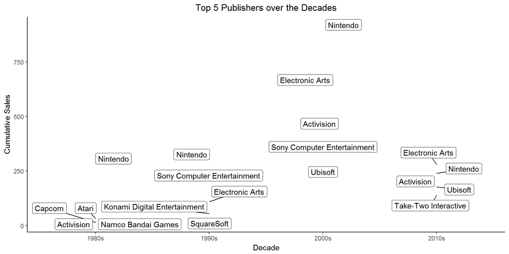

```r
top5bydecades %>%
  ggplot(aes(x = decade, y = Cum_Sales)) +
  geom_label_repel(aes(label = Publisher), label.size = 0.2) +
  labs(title = "Top 5 Publishers over the Decades", x = "Decade", y = "Cumulative Sales") +
  theme_classic() +
  theme(plot.title = element_text(hjust = 0.5))
```

Legendarily, **Nintendo** is the only one that has been in this short list for 4 decades. Founded in 1982, **Electronic Arts** since then has been climbing on this list step by step, and finally in the current decade becomes the **No.1** game publisher as of 2016.

Also, the gaming industry seems to have reached the apex during the **2000s**, even though we are only half way through the current decade, the absolute difference between **2000s** and **2010s** is still significantly large.

## 5. XBOX vs PlayStation

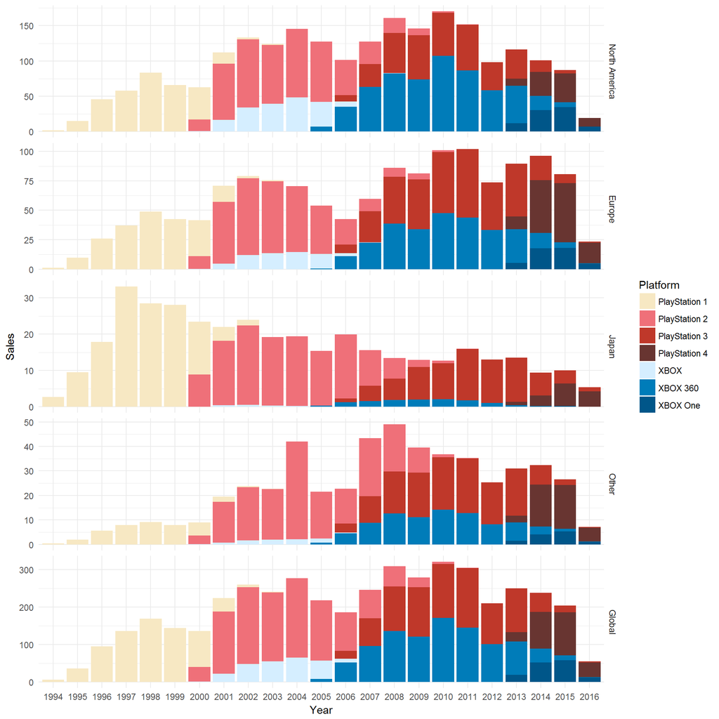

```r
xbox_ps <- vgsales %>%
  filter(Platform %in% c("XB", "X360", "XOne", "PS", str_c("PS", 2:4))) %>%
  mutate(Platform = plyr::mapvalues(Platform, from = c("XB", "X360", "XOne", "PS", str_c("PS", 2:4)),
                                    to = c(str_c("XBOX", c("", " 360", " One")), str_c("PlayStation ", 1:4)))) %>%
  group_by(Year, Platform) %>%
  summarise_if(is.numeric, sum) %>%
  ungroup() %>%
  gather(Region, Sales, NA_Sales:Global_Sales) %>%
  mutate(Region = str_replace(Region, "_Sales$", "") %>%
           factor(levels = c("NA", "EU", "JP", "Other", "Global"),
                  labels = c("North America", "Europe", "Japan", "Other", "Global"))) %>%
  filter(!str_detect(Year, "N/A|2017"))

xbox_ps %>%
  ggplot(aes(x = Year, y = Sales)) +
  geom_bar(aes(fill = Platform), stat = "identity") +
  facet_grid(Region~., scales = "free") +
  theme_minimal() +
  scale_fill_manual(values = c("PlayStation 1" = "#F7E8C3", "PlayStation 2" = "#EF7079", "PlayStation 3" = "#BF382A", "PlayStation 4" = "#683531",
                               "XBOX" = "#D5EEFF", "XBOX 360" = "#007CB9", "XBOX One" = "#005689"))
```

As two very (if not the most) famous gaming consols, **XBOX** and **PlayStation** have been competing against each other for over a decade.